# Zero inflated Beta-binomial in brms

Hayden Rabel

2022-03-14

## The Beta-binomial distribution

The Stan definition of the Beta-binomial probability mass function is:

If $N \in \mathbb{N}, \alpha \in \mathbb{R}^+,$ and $\beta \in \mathbb{R}^+$, then for $n \in 0,\dots,N$,

$$\text{BetaBinomial}(n|N,\alpha,\beta) = \binom{n}{N}\frac{B(n + \alpha, N - n + \beta)}{B(\alpha, \beta)},$$

where the beta function $B(u,v)$ is defined for $u \in \mathbb{R}^+$ and $v \in \mathbb{R}^+$ by

$$B(u,v) = \frac{\Gamma(u)\Gamma(v)}{\Gamma(u + v)}.$$

This distribution has a bunch of interesting properties on Wikipedia:

- $n = 1$ reduces it to the Bernoulli distribution.
- $\alpha = \beta = 1$ yields the discrete uniform distribution from $0$ to $n$.
- For large $\alpha, \beta$ it approximates the binomial distribution.
- For large $n, \beta$ it contains the negative binomial distribution in the limit.
- It is also a one-dimensional version of the Dirichlet-multinomial distribution.
- When $\alpha, \beta \in \mathbb{N}$ it is sometimes known as the negative hypergeometric distribution

## As a response distribution

The $\alpha$ and $\beta$ parameterisation above is tricky for `bmrs`, as both parameters control the shape. So, if we want to link predictors to the response, we would need to link to both $\alpha$ and $\beta$.

Thankfully, the Beta distribution can be re-parameterised in terms of it’s mean $\mu \in (0, 1)$ and $\phi = \alpha + \beta > 0$ using

$\alpha = \mu \phi$ and $\beta = (1 - \mu)\phi$.

$\phi$ is interpreted like precision, sample size, or a measure of overdispersion:

- $\mu < 0.5 \implies \beta > \alpha$ and as $\phi$ increases, so does $\beta$ which increases right-skew, i.e., overdispersion.
- $\mu > 0.5 \implies \beta < \alpha$ and as $phi$ increases, so does $\alpha$ which increases left-skew.
- $\mu = 0.5 \implies \beta = \alpha$ and as the distribution is symmetric, with $\phi = 2$ creating a uniform shape, $\phi < 2$ concave, and $\phi > 2$ convex bell-shaped.

We can rewrite the PMF above as

$$\text{BetaBinomial}(n|N,\mu \phi, (1 - \mu)\phi) = \binom{n}{N}\frac{B(n + \mu \phi, N - n + (1 - \mu)\phi)}{B(\mu \phi, (1 - \mu)\phi)}.$$

Now we can use a logit link function to obtain a linear predictor for $\mu$, the expected average success probability, as

$$\ln\left(\frac{\mu}{1 -\mu}\right) = \eta = \beta_0 + \beta_1 x_1 + \dots ,$$

where

$$\mu = \frac{\exp(\eta)}{\exp(\eta) + 1}.$$

## With zero inflation

It’s likely that, in situations where the observed data has low average success probability, $\mu$, the standard Beta-binomial distribution should be able to account for excess zeros by estimating $\phi$ densities with higher modes.

Though in situations where this is not enough, or it’s suspected that there is a separate un-measured process creating these extra zeros, we can try a zero-inflated response distribution, specifically a mixture model where there is a probability $\theta$ of drawing a zero, and a $1 - \theta$ probability of drawing from the Beta-binomial distribution:

$$p(n|N,\mu \phi, (1 - \mu)\phi,\theta) = \begin{cases}
\theta + (1 - \theta) \times \text{BetaBinomial}(0|N,\mu \phi, (1 - \mu)\phi) &\text{if}~n=0, \text{and}\\
(1 - \theta) \times \text{BetaBinomial}(n|N,\mu \phi, (1 - \mu)\phi) &\text{if}~n>0.
\end{cases}$$

I.e., some of the zeros are contributed by the Beta-binomial distribution and some by a Bernoulli process, with mixing probability $\theta$.

## Example: Multilevel tadpoles

### Data

East African reed frog data from [Vonesh, J. R., & Bolker, B. M. (2005)](https://doi.org/10.1890/04-0535) with a few extra zeros added in.

```r
library(dplyr)
library(tidyr)
library(ggplot2)
library(brms)
data(reedfrogs, package = "rethinking")

# probability of zero survivals
set.seed(0)
zi <- 0.1

# update
reedfrogs <-
  reedfrogs %>%
  mutate(tank = 1:nrow(.),
         not_zero = runif(nrow(.)) > zi,
         across(c(surv, propsurv), ~ .x * not_zero)) %>%
  as_tibble()
reedfrogs
```

```
# A tibble: 48 x 7
   density pred  size   surv propsurv  tank not_zero
     <int> <fct> <fct> <int>    <dbl> <int> <lgl>
 1      10 no    big       9      0.9     1 TRUE
 2      10 no    big      10      1       2 TRUE
 3      10 no    big       7      0.7     3 TRUE
 4      10 no    big      10      1       4 TRUE
 5      10 no    small     9      0.9     5 TRUE
 6      10 no    small     9      0.9     6 TRUE
 7      10 no    small    10      1       7 TRUE
 8      10 no    small     9      0.9     8 TRUE
 9      10 pred  big       4      0.4     9 TRUE
10      10 pred  big       9      0.9    10 TRUE
# ... with 38 more rows
```

### Model 1: plain binomial

$$\begin{aligned}
surv_i &\sim \text{Binomial}(n_i,p_i)\\
\text{logit}(p_i) &= \alpha\\
\alpha &\sim \text{Normal}(0, 1.5).&
\end{aligned}$$

```r
m1 <-
  brm(data = reedfrogs,
      family = binomial,
      formula = surv | trials(density) ~ 1,
      prior = prior(normal(0, 1.5), class = Intercept),
      iter = 2000, warmup = 1000, chains = 4,
      seed = 0,
      file = 'fits/m1.rds')
m1
```

```
 Family: binomial
  Links: mu = logit
Formula: surv | trials(density) ~ 1
   Data: reedfrogs (Number of observations: 48)
  Draws: 4 chains, each with iter = 2000; warmup = 1000; thin = 1;
         total post-warmup draws = 4000

Population-Level Effects:
          Estimate Est.Error l-95% CI u-95% CI Rhat Bulk_ESS Tail_ESS
Intercept     0.70      0.06     0.58     0.83 1.00     1372     1978

Draws were sampled using sampling(NUTS). For each parameter, Bulk_ESS
and Tail_ESS are effective sample size measures, and Rhat is the potential
scale reduction factor on split chains (at convergence, Rhat = 1).
```

### Model 2: Binomial with pooled varying intercepts

$$\begin{aligned}
surv_i &\sim \text{Binomial}(n_i,p_i)\\
\text{logit}(p_i) &= \alpha_{\text{tank}[i]}\\
\alpha_j &\sim \text{Normal}(0, 1.5) &\text{for}~j=1,\dots,48.
\end{aligned}$$

```r
m2 <-
  brm(data = reedfrogs,
      family = binomial,
      formula = surv | trials(density) ~ 0 + factor(tank),
      prior = prior(normal(0, 1.5), class = b),
      iter = 2000, warmup = 1000, chains = 4,
      seed = 0,
      file = 'fits/m2.rds')
m2
```

```
 Family: binomial
  Links: mu = logit
Formula: surv | trials(density) ~ 0 + factor(tank)
   Data: reedfrogs (Number of observations: 48)
  Draws: 4 chains, each with iter = 2000; warmup = 1000; thin = 1;
         total post-warmup draws = 4000

Population-Level Effects:
             Estimate Est.Error l-95% CI u-95% CI Rhat Bulk_ESS Tail_ESS
factortank1      1.72      0.75     0.37     3.28 1.00     5380     2810
factortank2      2.42      0.91     0.81     4.36 1.00     5172     2787
factortank3      0.76      0.65    -0.47     2.08 1.00     5851     2616
factortank4      2.38      0.91     0.78     4.37 1.00     5482     2438
factortank5      1.71      0.76     0.32     3.34 1.00     5263     2507
factortank6      1.70      0.76     0.29     3.31 1.00     5425     2627
factortank7      2.44      0.94     0.80     4.51 1.00     4860     2231
factortank8      1.72      0.75     0.38     3.27 1.00     5515     3330
factortank9     -0.37      0.62    -1.67     0.83 1.00     5179     2510
factortank10     1.71      0.77     0.37     3.39 1.00     6278     2710
factortank11    -2.40      0.90    -4.33    -0.82 1.00     6127     2883
factortank12     0.37      0.61    -0.81     1.57 1.00     5266     3112
factortank13     0.76      0.61    -0.39     1.98 1.00     5955     3191
factortank14    -0.00      0.60    -1.20     1.14 1.00     5486     2816
factortank15     1.72      0.78     0.36     3.35 1.00     4935     2727
factortank16     1.72      0.77     0.34     3.38 1.00     5465     2633
factortank17     2.54      0.67     1.38     3.97 1.00     5202     2937
factortank18     2.15      0.60     1.06     3.37 1.00     5084     3069
factortank19     1.81      0.53     0.83     2.91 1.00     6054     3162
factortank20     3.08      0.82     1.64     4.84 1.00     6289     2510
factortank21     2.14      0.60     1.08     3.44 1.00     4917     2695
factortank22     2.14      0.62     1.04     3.42 1.00     6575     2988
factortank23     2.14      0.59     1.08     3.38 1.00     5088     2716
factortank24     1.53      0.51     0.59     2.59 1.00     5096     2821
factortank25    -1.10      0.44    -2.01    -0.27 1.00     4874     2778
factortank26     0.08      0.40    -0.71     0.90 1.00     5673     2929
factortank27    -1.53      0.51    -2.58    -0.60 1.00     5770     3042
factortank28    -3.11      0.82    -4.89    -1.67 1.00     5269     2757
factortank29     0.08      0.40    -0.69     0.86 1.00     5884     3091
factortank30     1.30      0.47     0.41     2.24 1.00     5816     2933
factortank31    -0.73      0.42    -1.55     0.06 1.00     5935     2917
factortank32    -0.39      0.40    -1.19     0.37 1.00     5860     3218
factortank33     2.84      0.65     1.68     4.23 1.00     5500     2767
factortank34     2.45      0.56     1.45     3.69 1.00     5066     2406
factortank35     2.47      0.59     1.43     3.69 1.00     6132     3133
factortank36     1.92      0.50     0.99     2.97 1.00     5883     2643
factortank37     1.91      0.48     1.02     2.94 1.00     5035     2557
factortank38     3.36      0.79     1.99     5.12 1.00     5570     2560
factortank39     2.47      0.58     1.44     3.72 1.00     4897     2784
factortank40     2.15      0.52     1.24     3.28 1.00     5164     3012
factortank41    -1.90      0.46    -2.86    -1.08 1.00     5068     3095
factortank42    -0.64      0.35    -1.35     0.03 1.00     5159     3144
factortank43    -0.52      0.35    -1.23     0.15 1.00     4985     2879
factortank44    -0.40      0.33    -1.08     0.25 1.00     5387     2953
factortank45     0.51      0.35    -0.15     1.21 1.00     5409     3028
factortank46    -0.64      0.34    -1.31     0.00 1.00     5203     3210
factortank47     1.92      0.49     1.03     2.94 1.00     5336     2851
factortank48    -3.34      0.76    -4.94    -2.00 1.00     5732     2763

Draws were sampled using sampling(NUTS). For each parameter, Bulk_ESS
and Tail_ESS are effective sample size measures, and Rhat is the potential
scale reduction factor on split chains (at convergence, Rhat = 1).
```

### Model 3a: Beta-binomial (custom)

$$\begin{aligned}
surv_i &\sim \text{BetaBinomial}(n_i,\bar{p_i},\phi)\\
\text{logit}(\bar{p_i}) &= \alpha\\
\alpha &\sim \text{Normal}(0, 1.5)\\
\phi &\sim \text{Gamma}(0.01, 0.01).
\end{aligned}$$

```r
beta_binomial2 <-
  custom_family("beta_binomial2", dpars = c("mu", "phi"),
                links = c("logit", "log"), lb = c(NA, 0),
                type = "int", vars = "vint1[n]")
stanvars <-
  stanvar(scode = "
  real beta_binomial2_lpmf(int y, real mu, real phi, int T) {
    return beta_binomial_lpmf(y | T, mu * phi, (1 - mu) * phi);
  }
  int beta_binomial2_rng(real mu, real phi, int T) {
    return beta_binomial_rng(T, mu * phi, (1 - mu) * phi);
  }",
  block = "functions")

m3a <-
  brm(data = reedfrogs,
      family = beta_binomial2,
      formula = surv | vint(density) ~ 1,
      prior = c(prior(normal(0, 1.5), class = Intercept),
                prior(gamma(0.01, 0.01), class = phi)),
      stanvars = stanvars,
      iter = 2000, warmup = 1000, chains = 4,
      seed = 0,
      file = 'fits/m3a.rds')

expose_functions(m3a, vectorize = TRUE)
log_lik_beta_binomial2 <- function(i, prep) {
  mu <- get_dpar(prep, "mu", i = i)
  phi <- get_dpar(prep, "phi", i = i)
  trials <- prep$data$vint1[i]
  y <- prep$data$Y[i]
  beta_binomial2_lpmf(y, mu, phi, trials)
}
posterior_predict_beta_binomial2 <- function(i, prep, ...) {
  mu <- get_dpar(prep, "mu", i = i)
  phi <- get_dpar(prep, "phi", i = i)
  trials <- prep$data$vint1[i]
  beta_binomial2_rng(mu, phi, trials)
}
posterior_epred_beta_binomial2 <- function(prep) {
  mu <- get_dpar(prep, "mu")
  trials <- prep$data$vint1
  trials <- matrix(trials, nrow = nrow(mu), ncol = ncol(mu), byrow = TRUE)
  mu * trials
}
m3a
```

```
 Family: beta_binomial2
  Links: mu = logit; phi = identity
Formula: surv | vint(density) ~ 1
   Data: reedfrogs (Number of observations: 48)
  Draws: 4 chains, each with iter = 2000; warmup = 1000; thin = 1;
         total post-warmup draws = 4000

Population-Level Effects:
          Estimate Est.Error l-95% CI u-95% CI Rhat Bulk_ESS Tail_ESS
Intercept     0.65      0.19     0.28     1.02 1.00     2669     2303

Family Specific Parameters:
    Estimate Est.Error l-95% CI u-95% CI Rhat Bulk_ESS Tail_ESS
phi     1.59      0.35     1.04     2.42 1.00     2927     2578

Draws were sampled using sampling(NUTS). For each parameter, Bulk_ESS
and Tail_ESS are effective sample size measures, and Rhat is the potential
scale reduction factor on split chains (at convergence, Rhat = 1).
```

### Model 3b: Beta-binomial (in-built)

```r
m3b <-
  brm(data = reedfrogs,
      family = beta_binomial(),
      formula = surv | trials(density) ~ 1,
      prior = c(prior(normal(0, 1.5), class = Intercept),
                prior(gamma(0.01, 0.01), class = phi)),
      stanvars = stanvars,
      iter = 2000, warmup = 1000, chains = 4,
      seed = 0,
      file = 'fits/m3b.rds')
m3b
```

```
 Family: beta_binomial
  Links: mu = logit; phi = identity
Formula: surv | trials(density) ~ 1
   Data: reedfrogs (Number of observations: 48)
  Draws: 4 chains, each with iter = 2000; warmup = 1000; thin = 1;
         total post-warmup draws = 4000

Population-Level Effects:
          Estimate Est.Error l-95% CI u-95% CI Rhat Bulk_ESS Tail_ESS
Intercept     0.65      0.19     0.28     1.02 1.00     2669     2303

Family Specific Parameters:
    Estimate Est.Error l-95% CI u-95% CI Rhat Bulk_ESS Tail_ESS
phi     1.59      0.35     1.04     2.42 1.00     2927     2578

Draws were sampled using sampling(NUTS). For each parameter, Bulk_ESS
and Tail_ESS are effective sample size measures, and Rhat is the potential
scale reduction factor on split chains (at convergence, Rhat = 1).
```

### Model 4: Zero-inflated beta-binomial

$$\begin{aligned}
surv_i &\sim \text{ZiBetaBinomial}(n_i,\bar{p_i},\phi,\theta)\\
\text{logit}(\bar{p_i}) &= \alpha\\
\alpha &\sim \text{Normal}(0, 1.5)\\
\phi &\sim \text{Gamma}(0.01, 0.01)\\
\theta &\sim \text{Beta}(1, 1).
\end{aligned}$$

```r
m4 <-
  brm(data = reedfrogs,
      family = zero_inflated_beta_binomial(),
      formula = surv | trials(density) ~ 1,
      prior = c(prior(normal(0, 1.5), class = Intercept),
                prior(gamma(0.01, 0.01), class = phi),
                prior(beta(1, 1), class = zi)),
      iter = 2000, warmup = 1000, chains = 4,
      seed = 0,
      file = 'fits/m4.rds')
m4
```

```
 Family: zero_inflated_beta_binomial
  Links: mu = logit; phi = identity; zi = identity
Formula: surv | trials(density) ~ 1
   Data: reedfrogs (Number of observations: 48)
  Draws: 4 chains, each with iter = 2000; warmup = 1000; thin = 1;
         total post-warmup draws = 4000

Population-Level Effects:
          Estimate Est.Error l-95% CI u-95% CI Rhat Bulk_ESS Tail_ESS
Intercept     0.92      0.19     0.53     1.28 1.00     2357     2343

Family Specific Parameters:
    Estimate Est.Error l-95% CI u-95% CI Rhat Bulk_ESS Tail_ESS
phi     2.43      0.61     1.42     3.75 1.00     2686     2782
zi      0.07      0.04     0.02     0.16 1.00     2846     2038

Draws were sampled using sampling(NUTS). For each parameter, Bulk_ESS
and Tail_ESS are effective sample size measures, and Rhat is the potential
scale reduction factor on split chains (at convergence, Rhat = 1).
```

### Compare

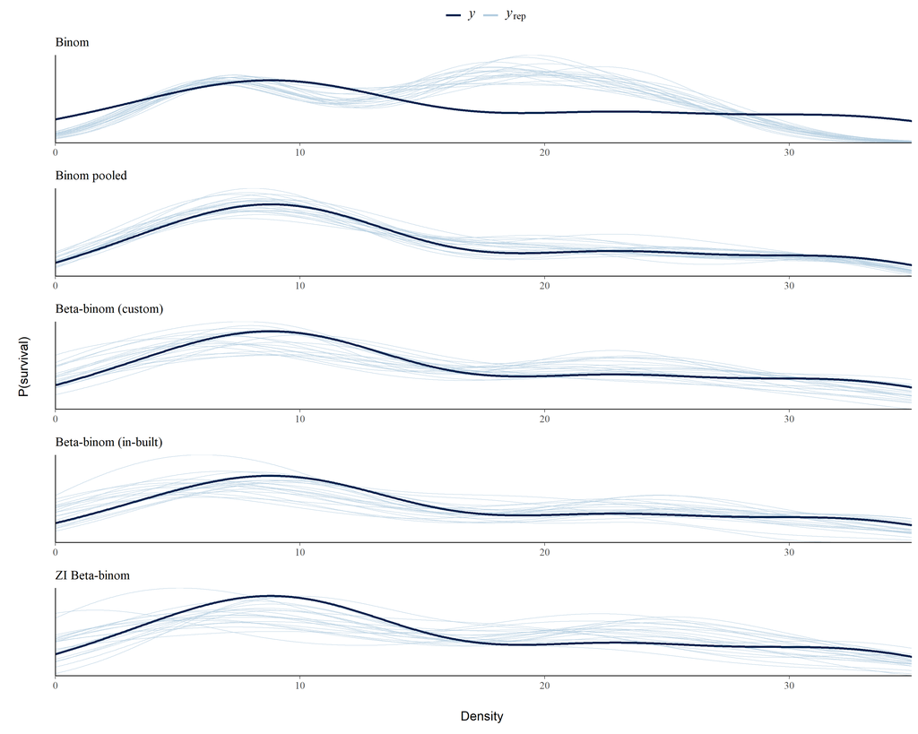

```r
set.seed(0)
draw_ids <- sample(1000:2000, 20)
ms <-
  list('Binom' = m1,
       'Binom pooled' = m2,
       'Beta-binom (custom)' = m3a,
       'Beta-binom (in-built)' = m3b,
       'ZI Beta-binom' = m4)
names(ms) %>%
  lapply(\(nm) {
    # try to draw with same rng seed, see note below
    set.seed(0)
    pp_check(ms[[nm]], ndraws = 20, draw_ids = draw_ids) +
      ggtitle(NULL, nm)
  }) %>%
  ggpubr::ggarrange(plotlist = .,
                    ncol = 1,
                    common.legend = TRUE) %>%
  ggpubr::ggarrange(ggpubr::text_grob('Density'),
                    ncol = 1,
                    heights = c(19, 1)) %>%
  ggpubr::ggarrange(ggpubr::text_grob('P(survival)', rot = 90),
                    .,
                    nrow = 1,
                    widths = c(1, 19))
```

**Note** that in the predictions above the $y_{\text{rep}}$’s for *custom* and *in-built* differ slightly as the **Stan** random number generator does not seem to be affected by `base::set.seed`.

```r
set.seed(0)
y_rep1 <- beta_binomial2_rng(0.5, 1, 10)
set.seed(0)
y_rep2 <- beta_binomial2_rng(0.5, 1, 10)
brms:::nlist(y_rep1, y_rep2, equal = y_rep1 == y_rep2)
```

```
$y_rep1
[1] 10

$y_rep2
[1] 1

$equal
[1] FALSE
```

However, the `loo` outputs also confirm equality of the posterior approximations:

```r
suppressWarnings(loo(m1, m2, m3a, m3b, m4)$diffs) %>%
  knitr::kable()
```

|  | elpd_diff | se_diff | elpd_loo | se_elpd_loo | p_loo | se_p_loo | looic | se_looic |
| --- | --- | --- | --- | --- | --- | --- | --- | --- |
| m2 | 0.00000 | 0.000000 | -121.8121 | 2.474195 | 43.122324 | 2.7390070 | 243.6241 | 4.948389 |
| m4 | -16.51069 | 5.127854 | -138.3227 | 6.110999 | 2.322770 | 0.4996949 | 276.6455 | 12.221998 |
| m3a | -18.87055 | 4.523802 | -140.6826 | 5.666111 | 2.178018 | 0.7225987 | 281.3652 | 11.332221 |
| m3b | -18.87055 | 4.523802 | -140.6826 | 5.666111 | 2.178018 | 0.7225987 | 281.3652 | 11.332221 |
| m1 | -238.58747 | 49.651738 | -360.3995 | 50.659933 | 12.815416 | 2.6723881 | 720.7991 | 101.319867 |